# Likehood Estimates for Outcome Rank Given Correlated Variable

Rich Seiter

Sunday, July 27, 2014

Based on idea described in my comment at http://infoproc.blogspot.com/2014/07/success-ability-and-all-that.html  
Also see the [original LessWrong post](http://lesswrong.com/lw/km6/why_the_tails_come_apart/)

Given a contributing factor X and a related outcome variable Y (with correlation r). Calculate likelihood that a given X will have the largest Y. An example case might be height as X and basketball ability as Y. Here we will focus on abstract normal variables with mean 0 and standard deviation 1. I have tried various correlations, but have primarily been using 0.4 or 0.65. Correlation for this simulation printed below.

Ideally this would be computed exactly. This analysis uses a simulation instead.

Also see the discussion of thresholded subsamples and their effect on correlations near the end.

First we generate a single set of data to give a sense of what we will see.

```r
Sys.time()
```

```
## [1] "2019-05-19 09:08:56 PDT"
```

```r
# These variables define our distribution
Xmean <- 0
Ymean <- 0
Xsd <- 1
Ysd <- 1
XYcor <- 0.65
#XYcor <- 0.4 # Published version
#XYcor <- 0.2
#XYcor <- 0.0

# Derived variables
XYmean <- c(Xmean, Ymean)
XYcov <- matrix(c(1, XYcor, XYcor, 1), nrow=2, ncol=2)

# Create our multivariate normal distribution using mvrnorm in MASS
require(MASS)
```

```r
#make this reproducible
set.seed(2)

# Don't make sample too large here, car scatterplot can be slow
examplePopSize <- 1e5
myDrawsExample <- mvrnorm(examplePopSize, mu=XYmean, Sigma=XYcov)
myDrawsExample <- data.frame(myDrawsExample)
colnames(myDrawsExample) <- c("X", "Y")

#check the mean, sd, and cor
apply(myDrawsExample, 2, mean)
```

```
##           X           Y
## 0.002145310 0.003447166
```

```r
apply(myDrawsExample, 2, sd)
```

```
##         X         Y
## 1.0005757 0.9997353
```

```r
cor(myDrawsExample)
```

```
##           X         Y
## X 1.0000000 0.6522454
## Y 0.6522454 1.0000000
```

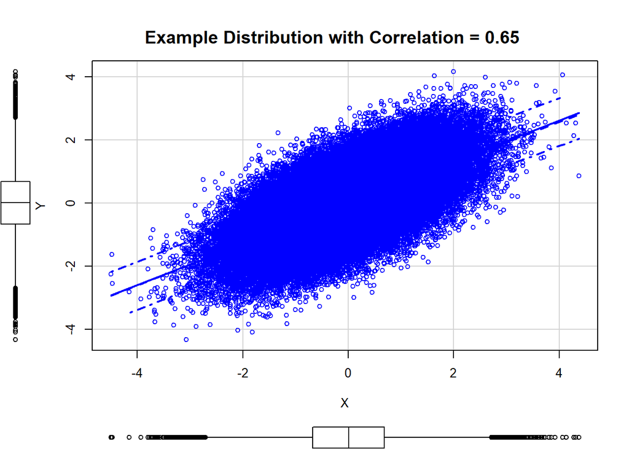

```r
# Plot the distribution
require(car)
scatterplot(Y ~ X, data=myDrawsExample, ellipse=TRUE,
            levels=c(0.5, 0.95, 0.99, 0.999, 0.9999))
title(paste("Example Distribution with Correlation =", XYcor))
```

## Simulate Multiple Populations

```r
Sys.time()
```

```
## [1] "2019-05-19 09:10:00 PDT"
```

```r
quick <- FALSE
if (quick) {
  # Quick version for debugging
  numRuns <- 1e2
  popSize <- 1e4
} else {
  # These values take about 15 minutes
  numRuns <- 1e4
  popSize <- 1e5
}

# Also record X for a top portion of Y
topProp <- 0.001 # Try 0.1%
topN <- popSize*topProp

XOfLargestY <- 1:numRuns
XOfTopPropY <- 1:(numRuns*topN)

#make this reproducible
set.seed(2)
for (i in 1:numRuns) {
  myDraws <- mvrnorm(popSize, mu=XYmean, Sigma=XYcov)
  myDraws <- data.frame(myDraws)
  colnames(myDraws) <- c("X", "Y")
  XOfLargestY[i] <- myDraws$X[which.max(myDraws$Y)]
  XOfTopPropY[((i-1)*topN+1):(i*topN)] <- myDraws$X[head(order(myDraws$Y, decreasing=TRUE), n=topN)]
}
Sys.time()
```

```
## [1] "2019-05-19 09:13:56 PDT"
```

## Look at the Results

How often does the largest Y have a given X value?

```r
require(lattice)
```

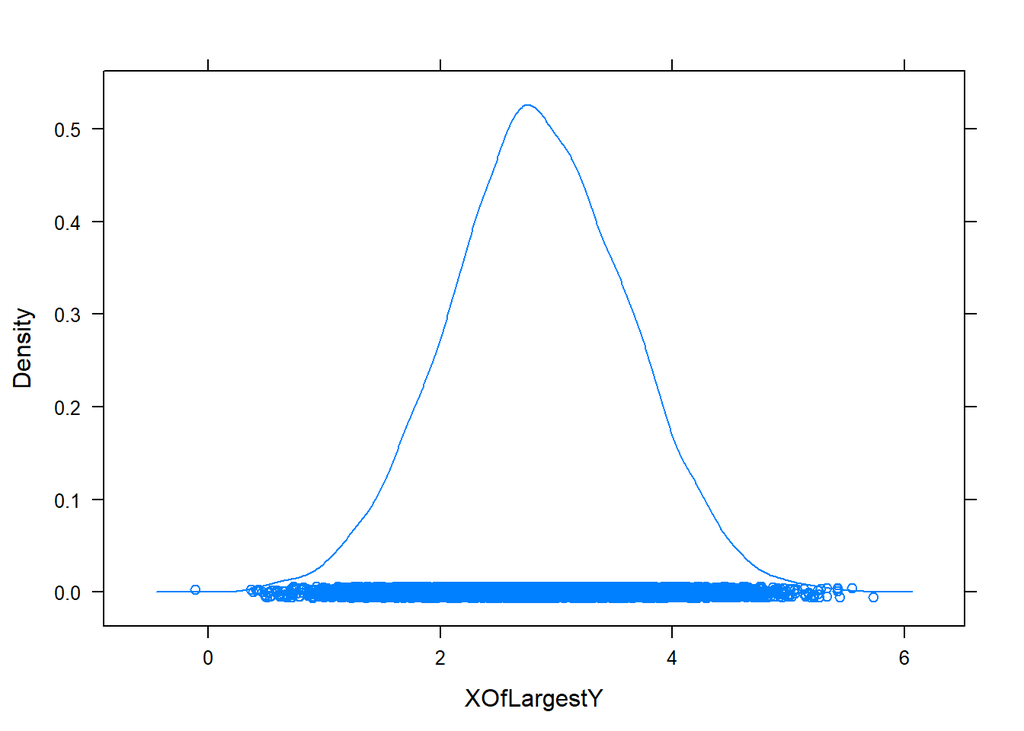

```r
densityplot(XOfLargestY)
```

```r
# Take a closer look at this distribution
summary(XOfLargestY)
```

```
##    Min. 1st Qu.  Median    Mean 3rd Qu.    Max.
##  -0.116   2.331   2.835   2.846   3.371   5.734
```

```r
mean(XOfLargestY)
```

```
## [1] 2.84608
```

```r
sd(XOfLargestY)
```

```
## [1] 0.7764496
```

How likely is it that any given person at level X will have the best Y?

I’m not sure about these calculations (especially the attempt to normalize to a probability). Feedback welcomed.

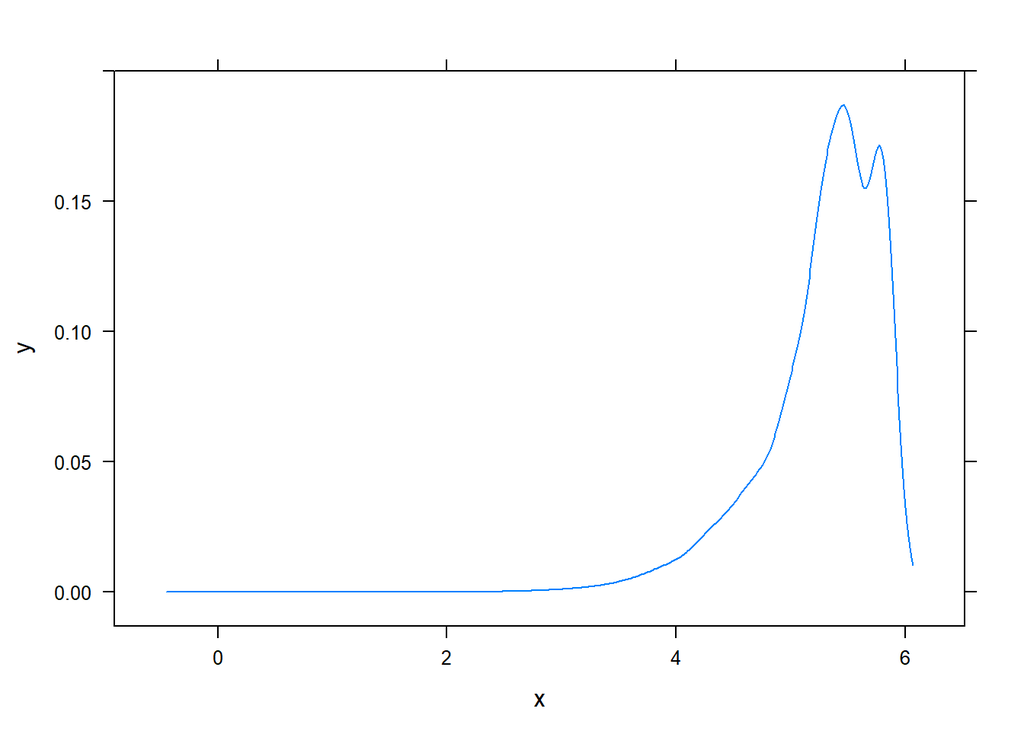

```r
obs_dvals <- density(XOfLargestY)
dvals <- dnorm(obs_dvals$x,mean=0,sd=1)
prob <- data.frame(x = obs_dvals$x,
                   y = obs_dvals$y / dvals / popSize # Attempt to normalize this to prob
                   )

xyplot(y ~ x, prob, type="l")
```

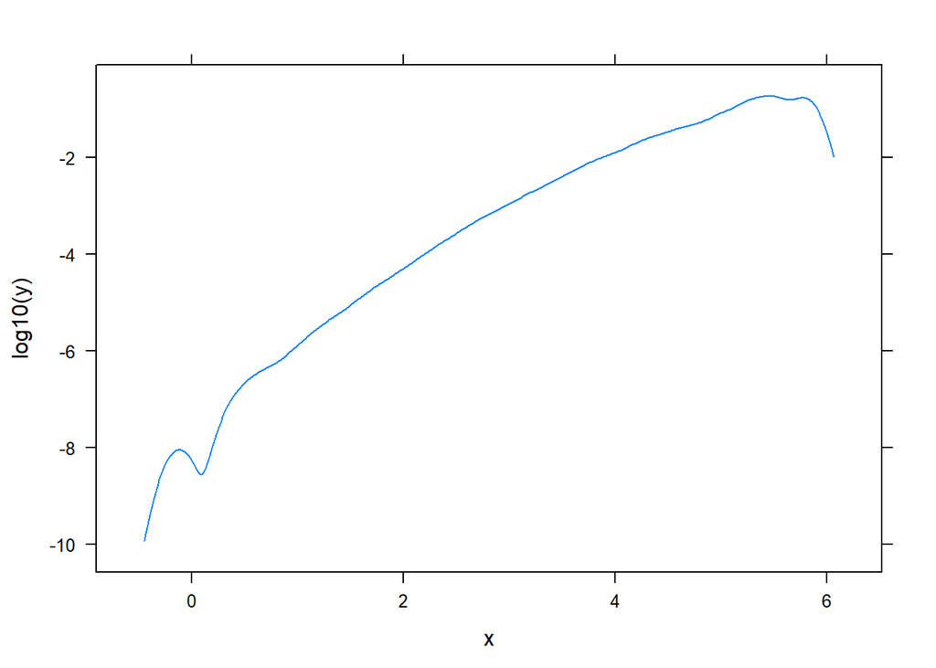

```r
xyplot(log10(y) ~ x, prob, type="l")
```

I believe the somewhat anomalous results at the extremes are due to sampling error. For example, when I increased the popSize from 1e4 to 1e5 (numRuns = 1e2) the peak and dip at the right moved right by about 0.7 to correspond. Then when I increased popSize to 1e6 the peak moved another ~0.3 right. The center of the XOfLargestY distribution also shifted right and the probabilities for 3-4SD X decreased.

## Now Look at the Top 0.1% of Y

How often does the top 0.1% of Y have a given X value?

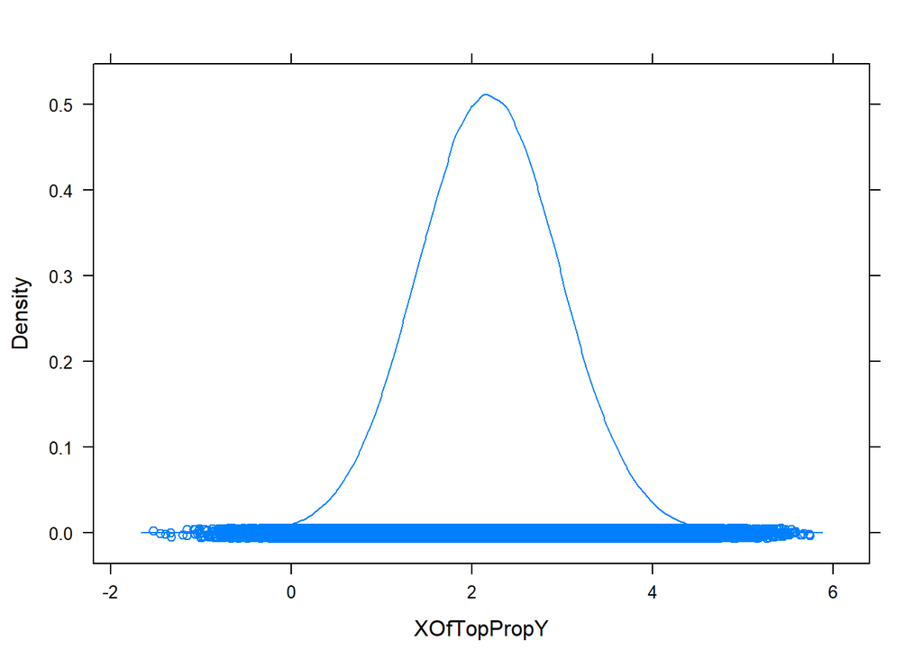

```r
densityplot(XOfTopPropY)
```

```r
# Take a closer look at this distribution
summary(XOfTopPropY)
```

```
##    Min. 1st Qu.  Median    Mean 3rd Qu.    Max.
##  -1.529   1.660   2.185   2.187   2.711   5.741
```

```r
mean(XOfTopPropY)
```

```
## [1] 2.186868
```

```r
sd(XOfTopPropY)
```

```
## [1] 0.7795286
```

How likely is it that any given person at level X will be in the top 0.1% of Y?

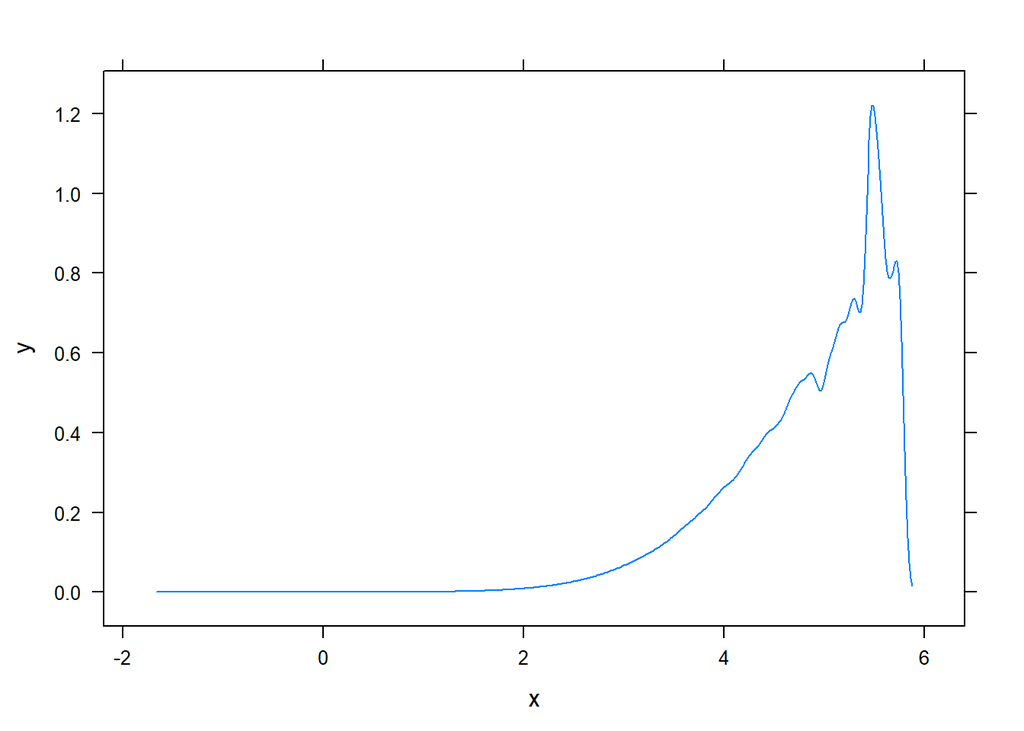

```r
obs_dvals1 <- density(XOfTopPropY)
dvals1 <- dnorm(obs_dvals1$x,mean=0,sd=1)
prob1 <- data.frame(x = obs_dvals1$x,
                    y = obs_dvals1$y / dvals1 / popSize * topN # Attempt to normalize this to prob
                    )

xyplot(y ~ x, prob1, type="l")
```

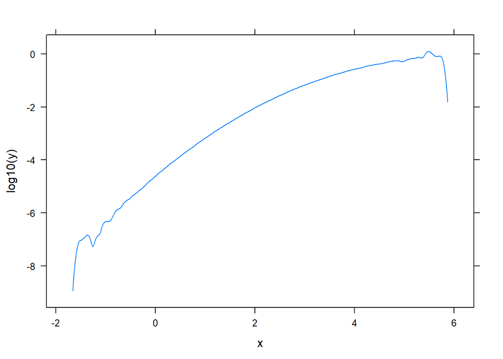

```r
xyplot(log10(y) ~ x, prob1, type="l")
```

Plot the densities together.

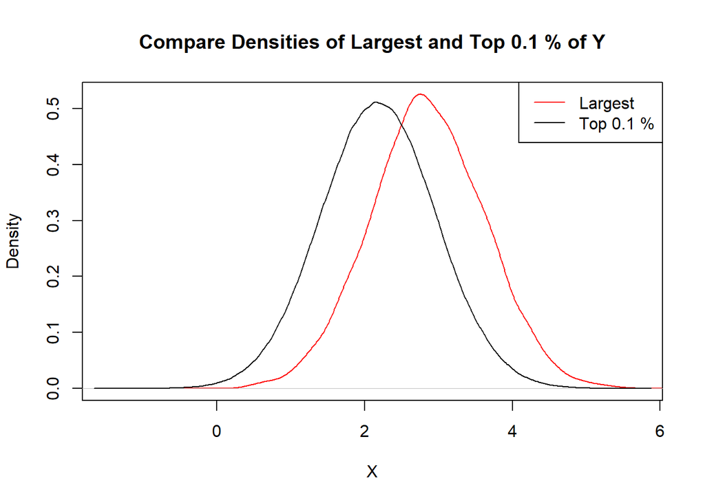

```r
plot(density(XOfLargestY), xlim=c(min(XOfTopPropY), max(XOfTopPropY)), col="red",
#plot(density(XOfLargestY), xlim=c(min(XOfLargestY), max(XOfLargestY)), col="red",
     main=paste("Compare Densities of Largest and Top", topProp*100, "% of Y"),
     xlab="X")
lines(density(XOfTopPropY))
legend("topright", legend=c("Largest", paste("Top", topProp*100, "%")), lty=1, col=c("red", "black"))
```

Note limiting of X axis. I think this is the valid range for inference.

```r
#plot(prob$x, log10(prob$y), xlim=c(min(XOfTopPropY), max(XOfTopPropY)),
plot(prob$x, log10(prob$y), xlim=c(min(XOfLargestY), max(XOfLargestY)),
     ylim=c(min(log10(prob1$y)),max(log10(prob1$y))),
     col="red",
     main=paste("Compare Per-Person Likelihood of Largest and Top",
                topProp*100, "% of Y"),
     xlab="X", ylab="log10(probability)", type="l")
lines(prob1$x, log10(prob1$y))
legend("topleft", legend=c("Largest", paste("Top", topProp*100, "%")),
       lty=1, col=c("red", "black"))

mod <- lm(log10(y) ~ x, data=prob, subset=prob$x>min(XOfLargestY) & prob$x<max(XOfLargestY))
abline(mod, col="red", lty=2)
summary(mod)
```

```
##
## Call:
## lm(formula = log10(y) ~ x, data = prob, subset = prob$x > min(XOfLargestY) &
##     prob$x < max(XOfLargestY))
##
## Residuals:
##     Min      1Q  Median      3Q     Max
## -1.4786 -0.2280  0.1346  0.3274  0.4371
##
## Coefficients:
##             Estimate Std. Error t value Pr(>|t|)
## (Intercept) -7.20525    0.03895  -185.0   <2e-16 ***
## x            1.28493    0.01189   108.1   <2e-16 ***
## ---
## Signif. codes:  0 '***' 0.001 '**' 0.01 '*' 0.05 '.' 0.1 ' ' 1
##
## Residual standard error: 0.4289 on 456 degrees of freedom
## Multiple R-squared:  0.9624, Adjusted R-squared:  0.9623
## F-statistic: 1.168e+04 on 1 and 456 DF,  p-value: < 2.2e-16
```

```r
10 ^ coef(mod)[2]
```

```
##        x
## 19.27203
```

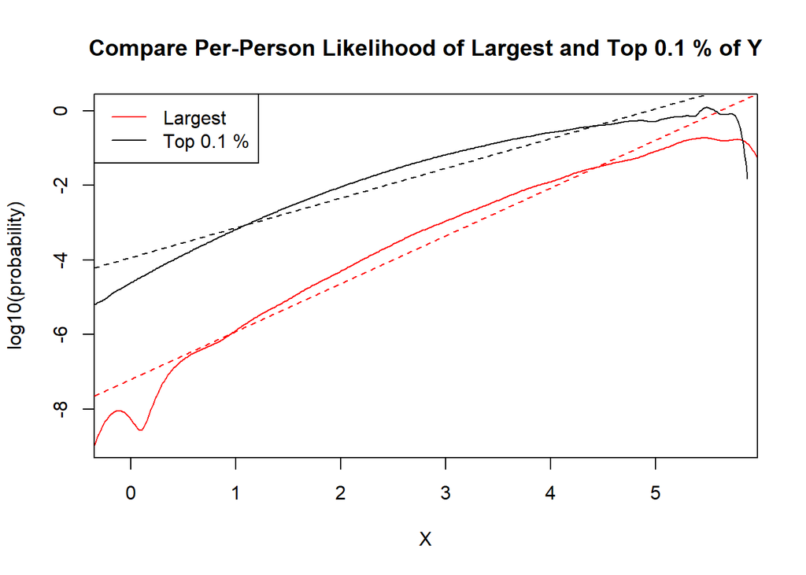

```r
mod1 <- lm(log10(y) ~ x, data=prob1, subset=prob1$x>min(XOfLargestY) & prob1$x<max(XOfLargestY))
abline(mod1, col="black", lty=2)
```

```r
summary(mod1)
```

```
##
## Call:
## lm(formula = log10(y) ~ x, data = prob1, subset = prob1$x > min(XOfLargestY) &
##     prob1$x < max(XOfLargestY))
##
## Residuals:
##      Min       1Q   Median       3Q      Max
## -0.76709 -0.29154  0.08925  0.30166  0.37691
##
## Coefficients:
##              Estimate Std. Error t value Pr(>|t|)
## (Intercept) -3.932479   0.032124 -122.42   <2e-16 ***
## x            0.797242   0.009806   81.31   <2e-16 ***
## ---
## Signif. codes:  0 '***' 0.001 '**' 0.01 '*' 0.05 '.' 0.1 ' ' 1
##
## Residual standard error: 0.3302 on 395 degrees of freedom
## Multiple R-squared:  0.9436, Adjusted R-squared:  0.9435
## F-statistic:  6611 on 1 and 395 DF,  p-value: < 2.2e-16
```

```r
10 ^ coef(mod1)[2]
```

```
##        x
## 6.269638
```

Try fitting models to these curves (above). Limit range and then fit log10(y) ~ x  
10 raised to the power of the coefficient for x estimates the multiplicative factor of probability for a 1 SD increase in X.

## Comments

Clearly this simulation model has many assumptions. The two that particularly concern me are:  
1. Normality (e.g. IQ is believed to have fat tails)  
2. That the sample population is large enough. I saw consistent changes when increasing popSize. I finally chose 1e5 as a compromise.

I think it best to only really consider the results in the X range where XOfLargestY has at least one value (and possibly ignore apparent extreme outliers).

## Berkson’s Paradox

[This Less Wrong comment](http://lesswrong.com/lw/km6/why_the_tails_come_apart/b5r2) notes the relevance of [Berkson’s Paradox](http://en.wikipedia.org/wiki/Berkson's_paradox)

Though not strictly applicable here (X and Y are not independent) it does raise the question of what correlations look like if we look at selected portions of the population.

Use the single example population created above. Look at > 2SD for X, Y, and both.

Notice how results change for different correlations. As correlations become small the sample with both >2SD becomes smaller.

Overall it looks like truncating the distributions decreases the measured correlations with the largest effect being if both X and Y are truncated. Compare the correlations below with the correlation of 0.65 for the full distribution.

```r
myDrawsSampleY2SD <- myDrawsExample[myDrawsExample$Y > 2,]

#check the mean, sd, and cor
apply(myDrawsSampleY2SD, 2, mean)
```

```
##        X        Y
## 1.538577 2.368934
```

```r
apply(myDrawsSampleY2SD, 2, sd)
```

```
##         X         Y
## 0.7787525 0.3308667
```

```r
cor(myDrawsSampleY2SD)
```

```
##           X         Y
## X 1.0000000 0.2693941
## Y 0.2693941 1.0000000
```

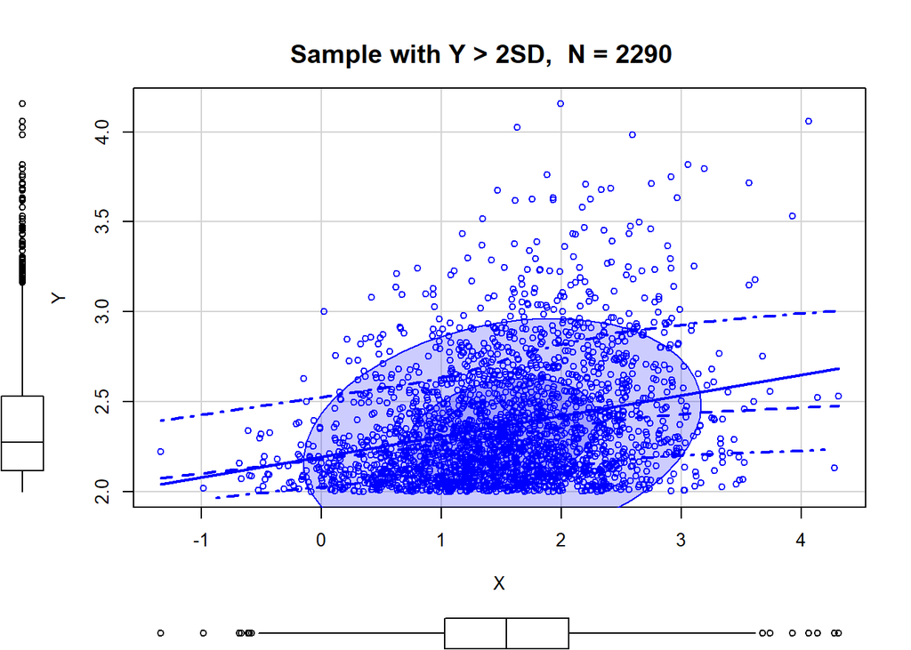

```r
# Plot the distribution
require(car)
scatterplot(Y ~ X, data=myDrawsSampleY2SD, ellipse=TRUE,
            levels=c(0.5, 0.95, 0.99, 0.999, 0.9999))
title(paste("Sample with Y > 2SD,  N =", nrow(myDrawsSampleY2SD)))
```

```r
myDrawsSampleX2SD <- myDrawsExample[myDrawsExample$X > 2,]

#check the mean, sd, and cor
apply(myDrawsSampleX2SD, 2, mean)
```

```
##        X        Y
## 2.373512 1.524454
```

```r
apply(myDrawsSampleX2SD, 2, sd)
```

```
##         X         Y
## 0.3334012 0.7880360
```

```r
cor(myDrawsSampleX2SD)
```

```
##           X         Y
## X 1.0000000 0.2467719
## Y 0.2467719 1.0000000
```

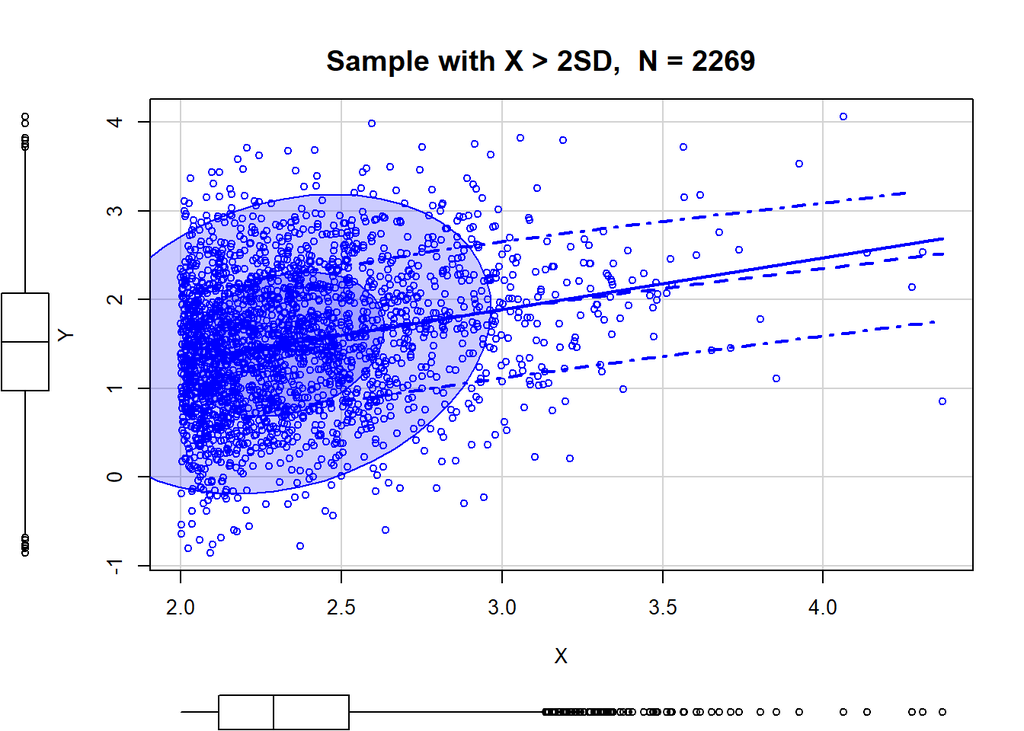

```r
# Plot the distribution
require(car)
scatterplot(Y ~ X, data=myDrawsSampleX2SD, ellipse=TRUE,
            levels=c(0.5, 0.95, 0.99, 0.999, 0.9999))
title(paste("Sample with X > 2SD,  N =", nrow(myDrawsSampleX2SD)))
```

```r
myDrawsSampleXorY2SD <- myDrawsExample[(myDrawsExample$X > 2) | (myDrawsExample$Y > 2),]

#check the mean, sd, and cor
apply(myDrawsSampleXorY2SD, 2, mean)
```

```
##        X        Y
## 1.869014 1.863618
```

```r
apply(myDrawsSampleXorY2SD, 2, sd)
```

```
##         X         Y
## 0.7372816 0.7437132
```

```r
cor(myDrawsSampleXorY2SD)
```

```
##            X          Y
## X  1.0000000 -0.3314512
## Y -0.3314512  1.0000000
```

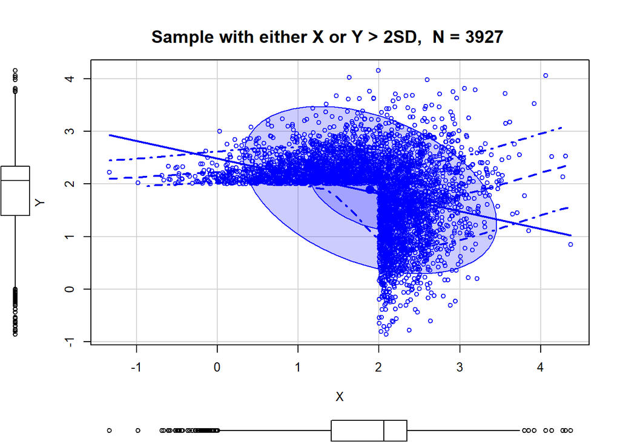

```r
# Plot the distribution
require(car)
scatterplot(Y ~ X, data=myDrawsSampleXorY2SD, ellipse=TRUE,
            levels=c(0.5, 0.95, 0.99, 0.999, 0.9999))
title(paste("Sample with either X or Y > 2SD,  N =", nrow(myDrawsSampleXorY2SD)))
```

```r
myDrawsSampleXY2SD <- myDrawsExample[(myDrawsExample$X > 2) & (myDrawsExample$Y > 2),]

#check the mean, sd, and cor
apply(myDrawsSampleXY2SD, 2, mean)
```

```
##        X        Y
## 2.482947 2.476923
```

```r
apply(myDrawsSampleXY2SD, 2, sd)
```

```
##         X         Y
## 0.3890359 0.3890922
```

```r
cor(myDrawsSampleXY2SD)
```

```
##          X        Y
## X 1.000000 0.113852
## Y 0.113852 1.000000
```

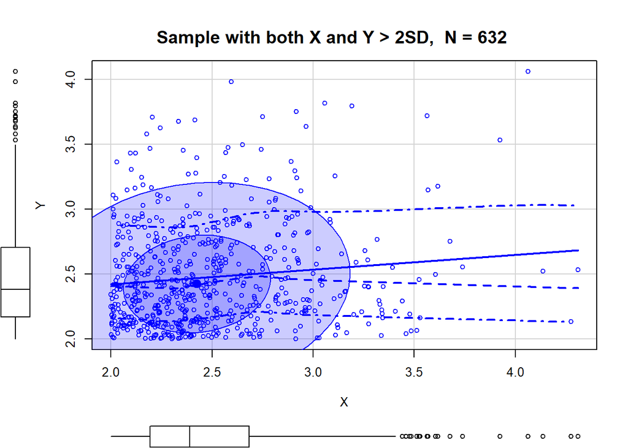

```r
# Plot the distribution
require(car)
scatterplot(Y ~ X, data=myDrawsSampleXY2SD, ellipse=TRUE,
            levels=c(0.5, 0.95, 0.99, 0.999, 0.9999))
title(paste("Sample with both X and Y > 2SD,  N =", nrow(myDrawsSampleXY2SD)))
```

Compare the correlation for this group of 0.113852 to the correlation for the original data of 0.6522454

And lastly look above a diagonal line.

```r
myDrawsSampleXYsum <- myDrawsExample[(myDrawsExample$Y + myDrawsExample$X) > 2,]

#check the mean, sd, and cor
apply(myDrawsSampleXYsum, 2, mean)
```

```
##        X        Y
## 1.459797 1.456569
```

```r
apply(myDrawsSampleXYsum, 2, sd)
```

```
##         X         Y
## 0.5705838 0.5754822
```

```r
cor(myDrawsSampleXYsum)
```

```
##             X           Y
## X  1.00000000 -0.07241093
## Y -0.07241093  1.00000000
```

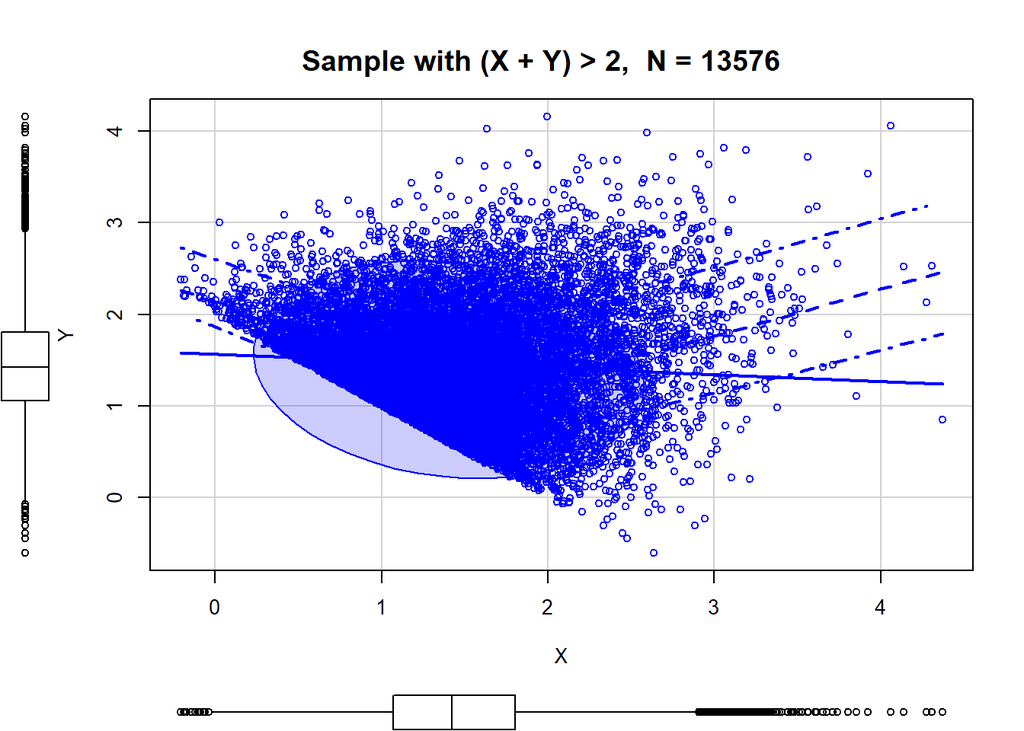

```r
# Plot the distribution
require(car)
scatterplot(Y ~ X, data=myDrawsSampleXYsum, ellipse=TRUE,
            levels=c(0.5, 0.95, 0.99, 0.999, 0.9999))
title(paste("Sample with (X + Y) > 2,  N =", nrow(myDrawsSampleXYsum)))
```

## Pear Shaped Scatterplot?

There is a popular meme that IQ is correlated with accomplishment, but above IQ 120 (say) that correlation disappears.

A pear shaped scatterplot (combination of elliptical moderate correlation at lower levels and circular no correlation above a threshold) has been proposed as a way of thinking about this. See [IQ, Creativity and the Twisted Pear](http://www.megasociety.org/noesis/149/iq&pear.html) by Grady Towers.

I believe the decreased correlation observed for thresholded subsamples above is a more parsimonious explanation for the popular observation of decreased correlation above a threshold (compared to no actual correlation in part of the distribution) and that the pear shaped scatterplot does not actually represent reality. (As an aside, if my conclusion is correct I find it ironic that the IQ/Pear article appeared in the newsletter for a high IQ society.)

See also the density simulations above for an explanation of how the bulk of high achievers in Y being not the highest X is consistent with high X still giving increasing returns in Y without a threshold effect.

Additional data/analysis/comments welcomed.

This reference has a relevant discussion: [Understanding Correlation: Factors that Affect the Size of r](http://eric.ed.gov/?id=EJ744793) and [PDF](http://www.psych.uncc.edu/pagoolka/jexpeduc2006p251.pdf). For example:

> It is well known among statisticians that, other things being equal, the value of r will be greater if there is more variability among the observations than if there is less variability. However, many researchers are unaware of this fact (Glass & Hopkins, 1996), and it is common for students in basic statistics courses (and even some students in intermediate- and advanced-level courses) to have difficulty comprehending this concept. Examples of this characteristic of r can be found quite easily, and it is often termed *range restriction*, *restriction of range*, or *truncated range* by authors of statistics and measurement textbooks…

Which is then followed by an SAT and College GPA example.

## Other Notes

A relevant point by another commenter: [True or False: Half of All 7-Footers are in the NBA](http://www.truthaboutit.net/2012/05/true-or-false-half-of-all-7-footers-are-in-the-nba.html)

Might be interesting to simulate correlation with an intermediate variable. For example, g/IQ/success

Completed at 2019-05-19 09:14:45